# Probability and Statistics

# Lab Assignment 1: Naive Bayes Classifier

## Work breakdown

- Victor Muryn
- Khrystyna Dmytriv
- Veronika Tkachyshyn

## Introduction

During the first three weeks, you learned a couple of essential notions and theorems, and one of the most important among them is the *Bayes theorem*.

One of its applications is **Naive Bayes classifier**, which is a probabilistic classifier whose aim is to determine which class some observation probably belongs to by using the Bayes formula:
$$\mathsf{P}(\mathrm{class}\mid
\mathrm{observation})=\frac{\mathsf{P}(\mathrm{observation}\mid\mathrm{class})\mathsf{P}(\mathrm{class})}{\mathsf{P}(\mathrm{observation})}$$

Under the strong independence assumption, one can calculate $\mathsf{P}(\mathrm{observation} \mid \mathrm{class})$ as
$$\mathsf{P}(\mathrm{observation}) =
\prod_{i=1}^{n} \mathsf{P}(\mathrm{feature}_i), \qquad
\mathsf{P}(\mathrm{observation} \mid \mathrm{class}) = \prod_{i=1}^{n}
\mathsf{P}(\mathrm{feature}_i \mid \mathrm{class}),$$
where $n$ is the total number of features describing a given observation. Thus, $\mathsf{P}(\mathrm{class}|\mathrm{observation})$ now can be calculated as

$$\mathsf{P}(\mathrm{class} \mid
\mathrm{\mathrm{observation}}) = \mathsf{P}(\mathrm{class})\times
\prod_{i=1}^{n}\frac{\mathsf{P}(\mathrm{feature}_i\mid
\mathrm{class})}{\mathsf{P}(\mathrm{feature}_i)}\tag{1}$$

All the terms on the right-hand side can be estimated from the data as respective relative frequencies;  
*see [this site](https://monkeylearn.com/blog/practical-explanation-naive-bayes-classifier/) for more detailed explanations*

## Data description

There are 5 datasets uploaded on the CMS (data.zip)

To determine your variant, take your team number from the list of teams on cms and take *mod 5* - this is the number of your data set.

- **0 - authors** This data set consists of citations of three famous writers: Edgar Alan Poe, Mary Wollstonecraft Shelley and HP Lovecraft. The task with this data set is to classify a piece of text with the author who was more likely to write it.

Each data set consists of two files: *train.csv* and *test.csv*. The first one you will need find the probabilities distributions for each of the features, while the second one is needed for checking how well your classifier works.

```r
# here goes a list of recommended libraries,
# though you may install other ones if they are needed
library(tidytext)
library(readr)
library(dplyr)
```

```r
library(ggplot2)
library(comprehenr)

# for diagrams
library(wordcloud)
library(RColorBrewer)
library(wordcloud2)
library(tm)
library(stringr)
```

## Outline of the work

1. **Data pre-processing** (includes removing punctuation marks and stop words, representing each message as a bag-of-words)
2. **Data visualization** (it’s time to plot your data!)
3. **Classifier implementation** (using the training set, calculate all the conditional probabilities in formula (1) and then use those to predict classes for messages in the testing set)
4. **Measurements of effectiveness of your classifier** (accuracy, precision and recall curves, F1 score metric etc)
5. **Conclusions**

*!! do not forget to submit both the (compiled) Rmd source file and the .html output !!*

## Data pre-processing

- Read the *.csv* data files.
- Сlear your data from punctuation or other unneeded symbols.
- Clear you data from stop words. You don’t want words as is, and, or etc. to affect your probabilities distributions, so it is a wise decision to get rid of them. Find list of stop words in the cms under the lab task.
- Represent each test message as its bag-of-words. Here: https://machinelearningmastery.com/gentle-introduction-bag-words-model/ you can find general introduction to the bag-of-words model and examples on to create it.
- It is highly recommended to get familiar with R dataframes, it would make the work much easier to do.
- Useful links:
  - https://steviep42.github.io/webscraping/book/bagofwords.html#tidytext - example of using *tidytext* to count frequencies of the words.
  - Basics of Text Mining in R: http://rstudio-pubs-static.s3.amazonaws.com/256588_57b585da6c054349825cba46685d8464.html . Note that it also includes an example on how to create a bag of words from your text document.

```r
test_path <- "data/0-authors/test.csv"
train_path <- "data/0-authors/train.csv"

stop_words <- read_file("stop_words.txt")
# https://stackoverflow.com/questions/27195912/why-does-strsplit-return-a-list
splitted_stop_words <- strsplit(stop_words, split = '\n')
splitted_stop_words <- splitted_stop_words[[1]]
```

```r
train <-  read.csv(file = train_path, stringsAsFactors = FALSE)
test <-  read.csv(file = test_path, stringsAsFactors = FALSE)
```

```r
# note the power functional features of R bring us!
tidy_text <-
  unnest_tokens(train, 'splitted', 'text', token = "words") %>%
  filter(!splitted %in% splitted_stop_words)

unique_words = tidy_text %>% count(splitted)
```

## Data visualization

Each time you work with some data, you need to understand it before you start processing it. R has very powerful tools to make nice plots and visualization. Show what are the most common words for negative and positive examples as a histogram, word cloud etc. Be creative!

```r
head(unique_words[order(unique_words$n, decreasing = TRUE), ], 10)
```

```
##       splitted    n
## 13529      one 1121
## 20943     upon  991
## 13267      now  815
## 21818     will  642
## 19796     time  516
## 6942      even  497
## 11934      man  484
## 22132      yet  480
## 16920     said  479
## 11457     like  450
```

```r
set.seed(5433) # for reproducibility
dev.new(width = 1000,
        height = 1000,
        unit = "px")
wordcloud(
  words = unique_words$splitted,
  freq = unique_words$n,
  max.words = 1000,
  random.order = FALSE,
  rot.per = 0.5,
  scale = c(4, .5),
  min.freq = 165,
  colors = brewer.pal(8, "Dark2")
)
```

[output not shown]

## Classifier implementation

```r
naiveBayes <- setRefClass(
  "naiveBayes",

  # attributes of classifier
  fields = list(
    count = "data.frame", # count of every word
    writers = "data.frame", # data about writers
    words = "numeric" # all number of words
  ),

  methods = list(
    # train our classifier
    fit = function(df) {
      .self$count <- df %>% count(author, splitted) # count number of words for each writer
      authors <- unique(count$author)
      sum_of_words <- sum(count$n)

      # dataset for writers
      writers_temp <- data.frame(
        author = character(0),
        probability = numeric(0),
        words = numeric(0)
      )

      # calculate data for each writer
      for (author in authors) {
        author_words <- sum(count$n[count$author == author])
        probability <- author_words / sum_of_words

        temp_df <- data.frame(
          author = author,
          probability = probability,
          words = author_words
        )

        writers_temp <- rbind(writers_temp, temp_df)
      }

      rownames(writers_temp) <- NULL
      .self$writers <- writers_temp

      # count words
      .self$words <- sum(.self$count$n)
    },

    # return prediction for a single message
    predict = function(message) {
      # clear income message
      message <- gsub('[\\(\\!\\)\\?\\,\\.]', '', message)
      message <- tolower(message)
      parts <- strsplit(message, split = " ")[[1]]
      parts <- parts[!parts %in% splitted_stop_words]

      # predicted result
      result_author <- ""
      max_probability <- 0

      for (i in 1:nrow(.self$writers)) {
        author <- .self$writers[i, ]

        # default probability
        # it's so huge, 'cause (0.5)^400 is very close to 0, that R rounds it to 0
        probability <- 1.797692e+308

        # for every word calculate probability of that word
        for (part in parts) {
          number <- .self$count$n[
            .self$count$author == author$author & .self$count$splitted == part
          ]

          number <- ifelse(length(number) == 0, 1, number + 1)

          probability <- probability * (number / (author$words + .self$words))
        }

        probability <- probability * author$probability

        # find max probability
        if (length(max_probability) == 0 | probability > max_probability) {
          max_probability <- probability
          result_author <- author$author
        }
      }

      return(result_author)
    },

    # score you test set so to get the understanding how well you model
    # works.
    # look at f1 score or precision and recall
    # visualize them
    # try how well your model generalizes to real world data!
    score = function(test_data) {
      predictions <- lapply(test_data$text, function(x) predict(x))

      correct_predictions <- sum(predictions == test_data$author)
      total_observation_count <- nrow(test_data)

      accuracy <- correct_predictions / total_observation_count

      return(accuracy)
    },

    viation = function(test_data) {
      result_df <- data.frame(
        text = character(0),
        author = character(0),
        prediction = character(0),
        result = logical(0)
      )

      for (i in 1:nrow(test_data)) {
        row <- test_data[i, ]
        text <- row$text
        author <- row$author

        prediction <- model$predict(text)

        correct <- ifelse(prediction == author, TRUE, FALSE)

        result_df <- rbind(result_df, data.frame(
          text = text,
          author = author,
          prediction = prediction,
          result = correct
        ))
      }

      authors <- unique(test_data$author)
      precision <- numeric()
      recall <- numeric()
      f1_score <- numeric()

      for (author in .self$writers$author) {
        true_positives <- sum(test_data$author == author & result_df$prediction == author)
        false_positives <- sum(test_data$author != author & result_df$prediction == author)
        false_negatives <- sum(test_data$author == author & result_df$prediction != author)

        precision_author <- true_positives / (true_positives + false_positives)
        recall_author <- true_positives / (true_positives + false_negatives)

        precision_author[is.na(precision_author)] <- 0
        recall_author[is.na(recall_author)] <- 0

        if (precision_author + recall_author == 0) {
          f1_score_author <- 0
        } else {
          f1_score_author <- 2 * (precision_author * recall_author) / (precision_author + recall_author)
        }

        precision <- c(precision, precision_author)
        recall <- c(recall, recall_author)
        f1_score <- c(f1_score, f1_score_author)
      }

      avg_precision <- mean(precision, na.rm = TRUE)
      avg_recall <- mean(recall, na.rm = TRUE)
      avg_f1_score <- mean(f1_score, na.rm = TRUE)

      cat("Precision:", precision, "\n")
      cat("Recall:", recall, "\n")
      cat("F1 Score:", f1_score, "\n\n")

      cat("Average Precision:", avg_precision, "\n")
      cat("Average Recall:", avg_recall, "\n")
      cat("Average F1 Score:", avg_f1_score, "\n")
      metrics <- data.frame(
        Metric = c("Precision", "Recall", "F1 Score"),
        Value = c(avg_precision, avg_recall, avg_f1_score)
      )

      ggplot(metrics, aes(x = Metric, y = Value, fill = Metric)) +
        geom_bar(stat = "identity") +
        labs(
          title = "Average Precision, Recall, and F1 Score",
          x = "Metric", y = "Value"
        ) +
        theme_minimal()
    }
  )
)
```

```r
model <- naiveBayes()
model$fit(tidy_text)
model$predict("I beg both your pardons but I can't be so much mistaken.")
```

```
## [1] "Edgar Alan Poe"
```

```r
cat("Accuracy:", model$score(test))
```

```
## Accuracy: 0.8299285
```

## Measure effectiveness of your classifier

Accuracy is not always a good metric for your classifier, so we decided to use F1 score metric.

$${\displaystyle F_{1} Score=2{\frac {\mathrm {precision} \cdot \mathrm
{recall} }{\mathrm {precision} +\mathrm {recall} }}}$$

Where, Precision and Recall equals to

$$Precision = \frac{true\ positive}{true\ positive\ + \ false \
positive}\\
Recall = \frac{true\ positive}{true\ positive\ + \ false \ negative}\\$$

```r
model$viation(test)
```

```
## Precision: 0.7992263 0.8676373 0.8439437
## Recall: 0.8702612 0.7892836 0.8145731
## F1 Score: 0.8332325 0.8266078 0.8289983
##
## Average Precision: 0.8369358
## Average Recall: 0.824706
## Average F1 Score: 0.8296129
```

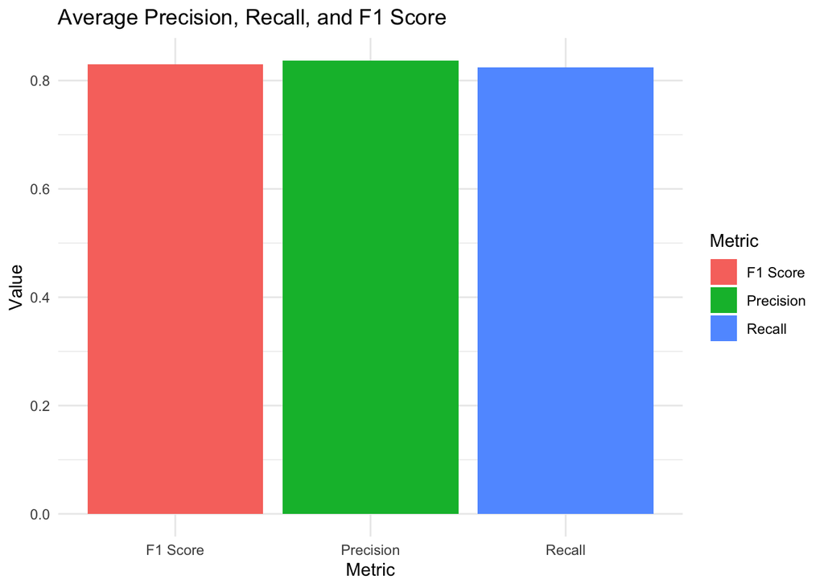

## Conclusions

- In this laboratory we created Naive Bayes Classifier. It uses Bayes formula at its core. The Naive Bayes classifier simplifies finding probability by assuming feature independence within each class, allowing us to calculate the likelihood as the product of individual feature probabilities within the class.
- The pros of this approach is its simplicity, efficiency and good performance on small datasets. The cons of Naive Bayes Classifier are independence assumption, sensitivity to feature scales and limited expressiveness.